# dataAnalysisOnSuicide

## **Question 1**

```r
rawdata <- read_csv("suicide.csv")
rawdata <- rawdata %>% mutate_if(is.character, factor)
rawdata %>% summary()
```

```
##         country           year          sex                 age
##  Austria    :  456   Min.   :1979   female:21888   15-24 years:7296
##  Hungary    :  456   1st Qu.:1990   male  :21888   25-34 years:7296
##  Iceland    :  456   Median :1999                  35-54 years:7296
##  Israel     :  456   Mean   :1999                  5-14 years :7296
##  Mauritius  :  456   3rd Qu.:2007                  55-74 years:7296
##  Netherlands:  456   Max.   :2016                  75+ years  :7296
##  (Other)    :41040
##   suicides_no        population
##  Min.   :    0.0   Min.   :     259
##  1st Qu.:    1.0   1st Qu.:   85113
##  Median :   14.0   Median :  380655
##  Mean   :  193.3   Mean   : 1664091
##  3rd Qu.:   91.0   3rd Qu.: 1305698
##  Max.   :22338.0   Max.   :43805214
##  NA's   :2256      NA's   :5460
```

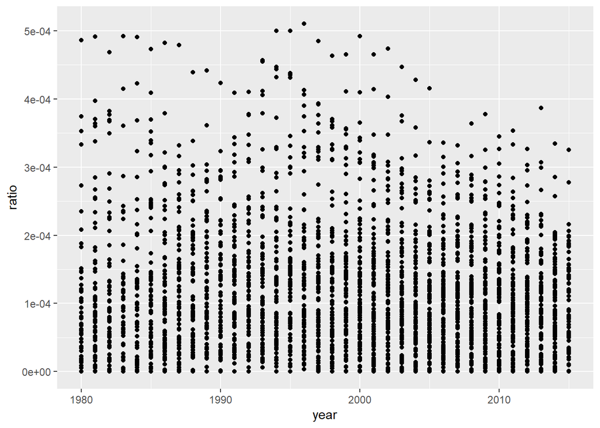

```r
nonaData <- rawdata
nonaData <- nonaData %>% filter( !is.na(suicides_no) ) %>% filter( !is.na(population))

d2 <- sqldf("SELECT country, year, SUM(suicides_no) AS totalsuicide, SUM(population) AS totalpopulation FROM nonaData WHERE year BETWEEN 1980 AND 2015 GROUP BY country, year")

d2 <- d2 %>% mutate( ratio = totalsuicide / totalpopulation)

d2 %>% ggplot(aes( year, ratio)) + geom_point()
```

```r
d2 %>% summary()
```

```
##    country               year       totalsuicide   totalpopulation
##  Length:2951        Min.   :1980   Min.   :    0   Min.   :    23801
##  Class :character   1st Qu.:1991   1st Qu.:   87   1st Qu.:  1611900
##  Mode  :character   Median :2000   Median :  546   Median :  4976200
##                     Mean   :1999   Mean   : 2673   Mean   : 20442457
##                     3rd Qu.:2008   3rd Qu.: 2044   3rd Qu.: 16710364
##                     Max.   :2015   Max.   :61420   Max.   :300078511
##      ratio
##  Min.   :0.000e+00
##  1st Qu.:4.925e-05
##  Median :9.918e-05
##  Mean   :1.189e-04
##  3rd Qu.:1.627e-04
##  Max.   :5.102e-04
```

```r
d2 %>% datatable
```

|  | country | year | totalsuicide | totalpopulation | ratio |
| --- | --- | --- | --- | --- | --- |
| 1 | Albania | 1987 | 73 | 2709600 | 2.69412459403602e-05 |
| 2 | Albania | 1988 | 63 | 2764300 | 2.2790579893644e-05 |
| 3 | Albania | 1989 | 68 | 2803100 | 2.42588562662766e-05 |
| 4 | Albania | 1992 | 47 | 2822500 | 1.6651904340124e-05 |
| 5 | Albania | 1993 | 73 | 2807300 | 2.60036333843907e-05 |
| 6 | Albania | 1994 | 50 | 2849300 | 1.75481697258976e-05 |
| 7 | Albania | 1995 | 88 | 2903400 | 3.03092925535579e-05 |
| 8 | Albania | 1996 | 89 | 2940200 | 3.0270049656486e-05 |
| 9 | Albania | 1997 | 170 | 2977300 | 5.70987135995701e-05 |
| 10 | Albania | 1998 | 154 | 3012700 | 5.11169382945531e-05 |

[output cut: 2941 more lines]

### *Answer:*

I only consider data which are reported, from 1980 to 2005 there were more outlier points in the graph. After 2005 outlier points were reduced. Thus, after 2005 tendency to commit suicide seems reduced.

## **Question 2**

```r
d3 <- rawdata
d3[is.na(d3)] <- 0


d3 <-  sqldf("SELECT country, year, SUM(suicides_no) AS totalsuicide, SUM(population) AS totalpopulation FROM d3 WHERE year BETWEEN 2006 AND 2015 GROUP BY country, year")
d3 <- d3 %>% mutate( ratio = totalsuicide / totalpopulation)
d3[is.infinite(d3[,5]), 5] <- 0
d3[is.na(d3)] <- 0
d3 <- arrange(d3, desc(ratio))
d3 %>% datatable
```

|  | country | year | totalsuicide | totalpopulation | ratio |
| --- | --- | --- | --- | --- | --- |
| 1 | Lithuania | 2013 | 1085 | 2806627 | 0.000386585036059298 |
| 2 | Lithuania | 2009 | 1138 | 3016497 | 0.000377258787262179 |
| 3 | Lithuania | 2008 | 1111 | 3053756 | 0.000363814266758706 |
| 4 | Lithuania | 2011 | 1018 | 2879805 | 0.000353496156857843 |
| 5 | Lithuania | 2010 | 1018 | 2949737 | 0.000345115513688169 |
| 6 | Lithuania | 2006 | 1049 | 3125767 | 0.000335597630917468 |
| 7 | Lithuania | 2014 | 930 | 2781577 | 0.00033434271278487 |
| 8 | Republic of Korea | 2011 | 15906 | 47798017 | 0.000332775311578302 |
| 9 | Lithuania | 2007 | 1025 | 3087867 | 0.000331944348639368 |
| 10 | Republic of Korea | 2010 | 15558 | 47598615 | 0.000326858249972189 |

[output cut: 1088 more lines]

```r
d3[c(1,8,14,15,16),]
```

```
##               country year totalsuicide totalpopulation        ratio
## 1           Lithuania 2013         1085         2806627 0.0003865850
## 8   Republic of Korea 2011        15906        47798017 0.0003327753
## 14           Suriname 2008          147          464789 0.0003162725
## 15 Russian Federation 2006        42614       135357462 0.0003148256
## 16             Guyana 2013          210          683867 0.0003070773
```

### *Answer:*

Russian Federation and Republic of Korea has more number of total suicide than Lithuania, Suriname and Guyana. But in terms of suicide rate (total suicide incidences / total population of countries) 1.Lithuania 2.Republic Of Korea 3.Suriname 4.Russian Federation 5.Guyana

## **Question 3**

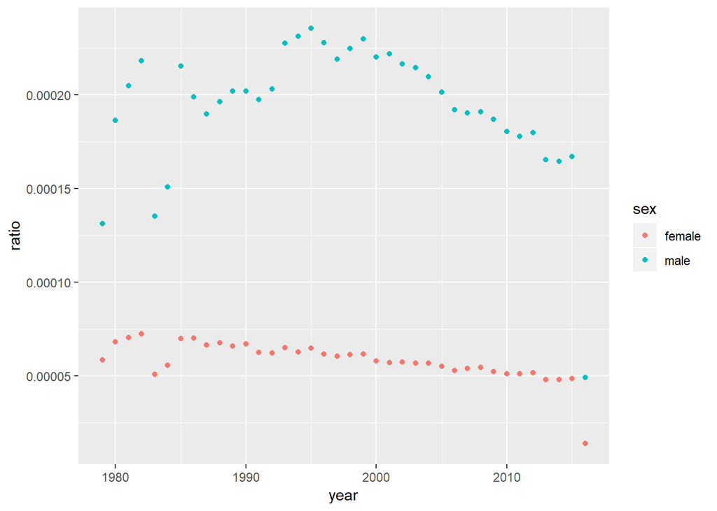

```r
d4 <- rawdata
d5 <- sqldf("SELECT year,sex, SUM(suicides_no) AS totalsuicide, SUM(population) AS totalpopulation FROM d4 GROUP BY sex ,year")
d5 <- d5 %>% mutate( ratio = totalsuicide / totalpopulation)
d5 %>% ggplot(aes(year, ratio, color = sex)) + geom_point()
```

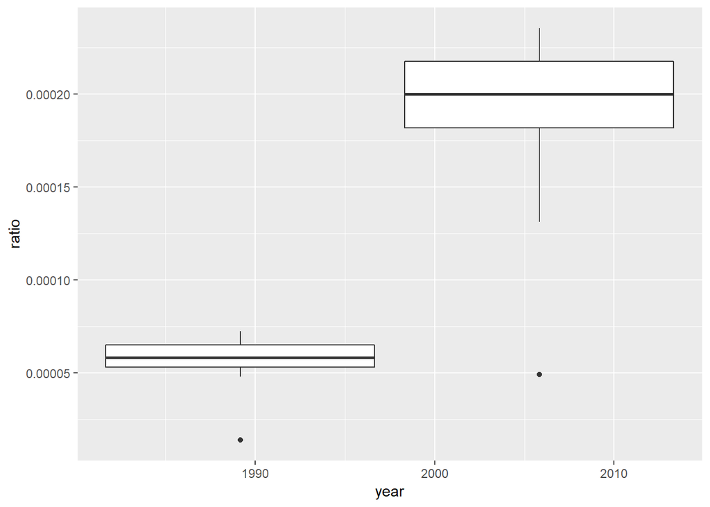

```r
d5 %>% ggplot(aes(year, ratio, group = sex)) + geom_boxplot()
```

### *Answer:*

Men’s tendency to suicide over the years showed a very fluctuating graph. On the other hand, women’s tendency to suicide over the years showed a very stable graph. As we see over the years both men and women are less likely to commit suicide. Around 2015 men’s suicide rate shows significant reduction.